# Yandex.Afisha business analysis

Goal: To study the data from Yandex.Afisha and analyze the sales and marketing investments.

Step 1. General Information  
Step 2. Reports and metrics

- Product analysis
- Sales analysis
- Marketing analysis

Step 3. Overall conclusion

## Step 1. General Information

```python
import pandas as pd
import numpy as np
import matplotlib.pyplot as plt
from scipy import stats as st
import seaborn as sns
costs_df = pd.read_csv(r'C:\Users\RoG\Desktop\Yandex_Course\costs_us.csv')
orders_df = pd.read_csv(r'C:\Users\RoG\Desktop\Yandex_Course\orders_log_us.csv')
visits_df = pd.read_csv(r'C:\Users\RoG\Desktop\Yandex_Course\visits_log_us.csv')
```

```python
costs_df.info(memory_usage='deep')
```

```
<class 'pandas.core.frame.DataFrame'>
RangeIndex: 2542 entries, 0 to 2541
Data columns (total 3 columns):
 #   Column     Non-Null Count  Dtype
---  ------     --------------  -----
 0   source_id  2542 non-null   int64
 1   dt         2542 non-null   object
 2   costs      2542 non-null   float64
dtypes: float64(1), int64(1), object(1)
memory usage: 206.2 KB
```

```python
costs_df.sample()
```

|  | source_id | dt | costs |
| --- | --- | --- | --- |
| 1284 | 4 | 2017-12-13 | 191.42 |

```python
costs_df['dt'] = pd.to_datetime(costs_df['dt'], format='%Y-%m-%d')
costs_df.info(memory_usage='deep')
```

```
<class 'pandas.core.frame.DataFrame'>
RangeIndex: 2542 entries, 0 to 2541
Data columns (total 3 columns):
 #   Column     Non-Null Count  Dtype
---  ------     --------------  -----
 0   source_id  2542 non-null   int64
 1   dt         2542 non-null   datetime64[ns]
 2   costs      2542 non-null   float64
dtypes: datetime64[ns](1), float64(1), int64(1)
memory usage: 59.7 KB
```

```python
visits_df.info(memory_usage='deep')
```

```
<class 'pandas.core.frame.DataFrame'>
RangeIndex: 359400 entries, 0 to 359399
Data columns (total 5 columns):
 #   Column     Non-Null Count   Dtype
---  ------     --------------   -----
 0   Device     359400 non-null  object
 1   End Ts     359400 non-null  object
 2   Source Id  359400 non-null  int64
 3   Start Ts   359400 non-null  object
 4   Uid        359400 non-null  uint64
dtypes: int64(1), object(3), uint64(1)
memory usage: 79.3 MB
```

```python
visits_df.sample()
```

|  | Device | End Ts | Source Id | Start Ts | Uid |
| --- | --- | --- | --- | --- | --- |
| 357183 | desktop | 2018-02-27 17:51:00 | 4 | 2018-02-27 17:43:00 | 3695437311118164720 |

```python
visits_df.columns = ['device', 'end_ts', 'source_id', 'start_ts', 'uid']
```

```python
visits_df['start_ts'] = pd.to_datetime(visits_df['start_ts'], format='%Y-%m-%dT%H:%M:%S')
visits_df['end_ts'] = pd.to_datetime(visits_df['end_ts'], format='%Y-%m-%dT%H:%M:%S')
```

```python
visits_df.device.value_counts()
```

```
desktop    262567
touch       96833
Name: device, dtype: int64
```

```python
visits_df['device'] = visits_df['device'].astype('category')
```

`It makes sense to convert the device data to category, since it's only two types of devices.`

```python
visits_df.info(memory_usage='deep')
```

```
<class 'pandas.core.frame.DataFrame'>
RangeIndex: 359400 entries, 0 to 359399
Data columns (total 5 columns):
 #   Column     Non-Null Count   Dtype
---  ------     --------------   -----
 0   device     359400 non-null  category
 1   end_ts     359400 non-null  datetime64[ns]
 2   source_id  359400 non-null  int64
 3   start_ts   359400 non-null  datetime64[ns]
 4   uid        359400 non-null  uint64
dtypes: category(1), datetime64[ns](2), int64(1), uint64(1)
memory usage: 11.3 MB
```

```python
visits_df.duplicated().value_counts()
```

```
False    359400
dtype: int64
```

```python
orders_df.info(memory_usage='deep')
```

```
<class 'pandas.core.frame.DataFrame'>
RangeIndex: 50415 entries, 0 to 50414
Data columns (total 3 columns):
 #   Column   Non-Null Count  Dtype
---  ------   --------------  -----
 0   Buy Ts   50415 non-null  object
 1   Revenue  50415 non-null  float64
 2   Uid      50415 non-null  uint64
dtypes: float64(1), object(1), uint64(1)
memory usage: 4.4 MB
```

```python
orders_df.sample()
```

|  | Buy Ts | Revenue | Uid |
| --- | --- | --- | --- |
| 9710 | 2017-09-29 18:17:00 | 7.94 | 2668507363237559802 |

```python
orders_df.columns = ['order_ts', 'revenue', 'uid']
orders_df['order_ts'] = pd.to_datetime(orders_df['order_ts'], format='%Y-%m-%dT%H:%M:%S')
orders_df.info(memory_usage='deep')
```

```
<class 'pandas.core.frame.DataFrame'>
RangeIndex: 50415 entries, 0 to 50414
Data columns (total 3 columns):
 #   Column    Non-Null Count  Dtype
---  ------    --------------  -----
 0   order_ts  50415 non-null  datetime64[ns]
 1   revenue   50415 non-null  float64
 2   uid       50415 non-null  uint64
dtypes: datetime64[ns](1), float64(1), uint64(1)
memory usage: 1.2 MB
```

```python
orders_df = orders_df.drop(orders_df.query('order_ts >= "2018-06-01"').index)
```

`The information about orders from June, 2018 was discovered in dataframe. I decided to drop it to avoid interfering with data from June, 2017, the initial month.`

```python
costs_df.duplicated().value_counts()
```

```
False    2542
dtype: int64
```

```python
orders_df.duplicated().value_counts()
```

```
False    50414
dtype: int64
```

```python
orders_df.describe()
```

|  | revenue | uid |
| --- | --- | --- |
| count | 50414.000000 | 5.041400e+04 |
| mean | 4.999678 | 9.098339e+18 |
| std | 21.818574 | 5.285642e+18 |
| min | 0.000000 | 3.135781e+14 |
| 25% | 1.220000 | 4.534221e+18 |
| 50% | 2.500000 | 9.102683e+18 |
| 75% | 4.890000 | 1.368294e+19 |
| max | 2633.280000 | 1.844617e+19 |

```python
orders_df.query('revenue == 0').count()
```

```
order_ts    51
revenue     51
uid         51
dtype: int64
```

```python
del_zeros = orders_df.query('revenue == 0')
#orders_df.drop(del_zeros.index, inplace=True)
orders_df = orders_df.drop(del_zeros.index)
```

#### Conclusion

For every dataframe date columns was changed format from 'object' to 'datetime' to save memory space. The 'device' column type in visits_df was changed to category for the same reason. No duplicated rows were found in any dataframe. 51 rows with zero revenue value were dropped from orders dataframe. The data beyond 365 days scope was removed from orders dataframe.

## Step 2. Reports and metrics

### Product

##### How many people use it every day, week, and month?

```python
visits_df['month'] = visits_df['start_ts'].astype('datetime64[M]')#.dt.month
visits_df['day'] = visits_df['start_ts'].dt.date
visits_df['year'] = visits_df['start_ts'].dt.year
visits_df['week'] = visits_df['start_ts'].astype('datetime64[W]')#dt.week
```

```python
dau_total = visits_df.groupby('day').agg({'uid': 'nunique'}).mean()
wau_total = visits_df.groupby(['year', 'week']).agg({'uid': 'nunique'}).mean()
mau_total = visits_df.groupby(['year', 'month']).agg({'uid': 'nunique'}).mean()
print('DAU:', int(dau_total), 'WAU:', int(wau_total), 'MAU:', int(mau_total))
```

```
DAU: 907 WAU: 5621 MAU: 23228
```

`In average, 907 people use the service daily, 5621 weekly, 23228 monthly. Let's take a look at distribution throughout the year:`

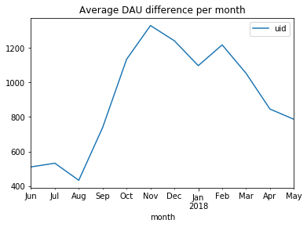

```python
visits_df.groupby(['day', 'month']).agg({'uid': 'nunique'}).groupby('month').mean().plot(title='Average DAU difference per month')
```

`Daily usage spikes towards the end of the year, peaking at november. The lowest number of people using the service per day is during summer.`

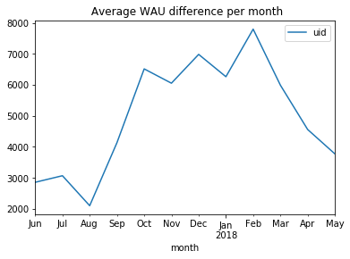

```python
visits_df.groupby(['week', 'month']).agg({'uid': 'nunique'}).groupby('month').mean().plot(title=' Average WAU difference per month')
```

`The weekly usage reaches its peak at February.`

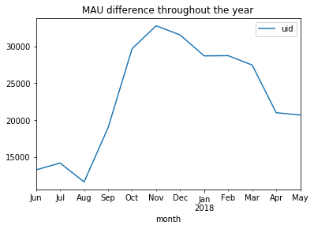

```python
visits_df.groupby(['month']).agg({'uid': 'nunique'}).plot(title='MAU difference throughout the year')#.mean()
```

`Most people use the service per month is through the period of October-March, reaching the peak at November-December.`

##### -How many sessions are there per day? (One user might have more than one session.)

```python
sessions_per_day = visits_df.groupby(['day']).agg({'uid': ['count','nunique']}).mean()
p = ((sessions_per_day[('uid', 'count')] - sessions_per_day[('uid', 'nunique')]) / sessions_per_day[('uid', 'count')])
print(sessions_per_day, '\n', "{:.2%}".format(p))
```

```
uid  count      987.362637
     nunique    907.991758
dtype: float64
 8.04%
```

`There is slightly (8%) more sessions than unique users visit the service per day, which means 8% of users return to use it again the same day.`

##### -What is the length of each session?

```python
visits_df['session_duration_sec'] = (visits_df['end_ts'] - visits_df['start_ts']).dt.seconds
m = visits_df['session_duration_sec'].mode().iloc[0]
print(m, '\n', len(visits_df.query('session_duration_sec == @m')))
```

```
60
 53029
```

`The most common session duration is 60 seconds (53029 cases).`

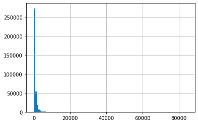

```python
visits_df['session_duration_sec'].hist(bins=100)
```

```python
visits_df['session_duration_sec'].describe()
```

```
count    359400.000000
mean        643.506489
std        1016.334786
min           0.000000
25%         120.000000
50%         300.000000
75%         840.000000
max       84480.000000
Name: session_duration_sec, dtype: float64
```

```python
visits_df.query('session_duration_sec == 0')
```

|  | device | end_ts | source_id | start_ts | uid | month | day | year | week | session_duration_sec |
| --- | --- | --- | --- | --- | --- | --- | --- | --- | --- | --- |
| 2 | touch | 2017-07-01 01:54:00 | 5 | 2017-07-01 01:54:00 | 7459035603376831527 | 2017-07-01 | 2017-07-01 | 2017 | 2017-06-29 | 0 |
| 4 | desktop | 2017-12-27 14:06:00 | 3 | 2017-12-27 14:06:00 | 9969694820036681168 | 2017-12-01 | 2017-12-27 | 2017 | 2017-12-21 | 0 |
| 28 | desktop | 2017-11-09 15:53:00 | 4 | 2017-11-09 15:53:00 | 17892541477379911957 | 2017-11-01 | 2017-11-09 | 2017 | 2017-11-09 | 0 |
| 32 | desktop | 2017-11-30 12:29:00 | 4 | 2017-11-30 12:29:00 | 13410401624913285510 | 2017-11-01 | 2017-11-30 | 2017 | 2017-11-30 | 0 |
| 54 | desktop | 2018-02-23 16:52:00 | 10 | 2018-02-23 16:52:00 | 13423278602430425332 | 2018-02-01 | 2018-02-23 | 2018 | 2018-02-22 | 0 |
| ... | ... | ... | ... | ... | ... | ... | ... | ... | ... | ... |
| 358511 | desktop | 2017-09-15 11:31:00 | 4 | 2017-09-15 11:31:00 | 6406595666419694649 | 2017-09-01 | 2017-09-15 | 2017 | 2017-09-14 | 0 |
| 358514 | desktop | 2018-01-16 23:57:00 | 5 | 2018-01-16 23:57:00 | 6457848932283204350 | 2018-01-01 | 2018-01-16 | 2018 | 2018-01-11 | 0 |
| 358522 | desktop | 2017-11-08 13:39:00 | 4 | 2017-11-08 13:39:00 | 6761309174945977743 | 2017-11-01 | 2017-11-08 | 2017 | 2017-11-02 | 0 |
| 358524 | touch | 2018-01-18 13:38:00 | 4 | 2018-01-18 13:38:00 | 4558073034499185861 | 2018-01-01 | 2018-01-18 | 2018 | 2018-01-18 | 0 |
| 358529 | desktop | 2018-05-06 20:27:00 | 5 | 2018-05-06 20:27:00 | 13482259146982443019 | 2018-05-01 | 2018-05-06 | 2018 | 2018-05-03 | 0 |

35794 rows × 10 columns

```python
len(visits_df)
```

```
359400
```

`As we can see, about 10% of sessions have 0 duration. That most probably due to low precision (to minutes, not seconds) in registration of start and end of a session. Most of the sessions are about 1 minute. Median time is 5 minutes.`

##### -How often do users come back?

```python
visits_min = visits_df.groupby('uid')['day'].min()
visits_min.name = 'first_visit'
visits_df = visits_df.merge(visits_min, on='uid',  how='left')
visits_df['first_visit'] = visits_df['first_visit'].astype('datetime64[M]')
visits_df = visits_df.sort_values(by=['uid', 'start_ts'])
visits_df['diff'] = visits_df.groupby(['uid'])['start_ts'].diff().dt.days #find difference between sessions for the same user
```

```python
ret_total =  visits_df.groupby('uid')['diff'].sum(min_count=1) #total retention (difference between first and last session)
ret_total.name = 'ret_total'
visits_df = visits_df.merge(ret_total, on='uid')
```

```python
visits_df.head()
```

|  | device | end_ts | source_id | start_ts | uid | month | day | year | week | session_duration_sec | first_visit | diff | ret_total |
| --- | --- | --- | --- | --- | --- | --- | --- | --- | --- | --- | --- | --- | --- |
| 0 | touch | 2018-03-01 17:33:00 | 3 | 2018-03-01 17:27:00 | 11863502262781 | 2018-03-01 | 2018-03-01 | 2018 | 2018-03-01 | 360 | 2018-03-01 | NaN | NaN |
| 1 | touch | 2018-02-06 15:57:00 | 2 | 2018-02-06 15:55:00 | 49537067089222 | 2018-02-01 | 2018-02-06 | 2018 | 2018-02-01 | 120 | 2018-02-01 | NaN | NaN |
| 2 | desktop | 2017-06-07 18:48:00 | 3 | 2017-06-07 18:47:00 | 297729379853735 | 2017-06-01 | 2017-06-07 | 2017 | 2017-06-01 | 60 | 2017-06-01 | NaN | NaN |
| 3 | desktop | 2017-09-18 23:07:00 | 2 | 2017-09-18 22:49:00 | 313578113262317 | 2017-09-01 | 2017-09-18 | 2017 | 2017-09-14 | 1080 | 2017-09-01 | NaN | 173.0 |
| 4 | desktop | 2018-02-18 15:26:00 | 2 | 2018-02-18 15:17:00 | 313578113262317 | 2018-02-01 | 2018-02-18 | 2018 | 2018-02-15 | 540 | 2017-09-01 | 152.0 | 173.0 |

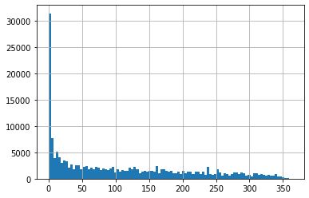

```python
visits_df['ret_total'].hist(bins=100)
```

```python
visits_df.query('ret_total == 0').head()
```

|  | device | end_ts | source_id | start_ts | uid | month | day | year | week | session_duration_sec | first_visit | diff | ret_total |
| --- | --- | --- | --- | --- | --- | --- | --- | --- | --- | --- | --- | --- | --- |
| 32 | touch | 2017-06-03 10:17:00 | 10 | 2017-06-03 10:13:00 | 1575281904278712 | 2017-06-01 | 2017-06-03 | 2017 | 2017-06-01 | 240 | 2017-06-01 | NaN | 0.0 |
| 33 | touch | 2017-06-03 17:48:00 | 10 | 2017-06-03 17:36:00 | 1575281904278712 | 2017-06-01 | 2017-06-03 | 2017 | 2017-06-01 | 720 | 2017-06-01 | 0.0 | 0.0 |
| 47 | desktop | 2018-01-27 20:13:00 | 5 | 2018-01-27 20:10:00 | 2464366381792757 | 2018-01-01 | 2018-01-27 | 2018 | 2018-01-25 | 180 | 2018-01-01 | NaN | 0.0 |
| 48 | desktop | 2018-01-28 14:49:00 | 5 | 2018-01-28 14:37:00 | 2464366381792757 | 2018-01-01 | 2018-01-28 | 2018 | 2018-01-25 | 720 | 2018-01-01 | 0.0 | 0.0 |
| 52 | desktop | 2017-11-24 10:14:19 | 5 | 2017-11-24 10:14:00 | 2551852515556206 | 2017-11-01 | 2017-11-24 | 2017 | 2017-11-23 | 19 | 2017-11-01 | NaN | 0.0 |

```
Most of the users return the same day or never return at all. For the rest of the users it is better to create retention groups:
Retention 0d, 1d, 3d, 7d, 14d, 30d, 3m, 6m, 1y

0d retention includes both who returned the same day and never returned at all.
```

```python
lifetime_list = ['0 days', '1 day', '3 days', '7 days', '14 days', '30 days', '90 days', '180 days', '>180 days']
def assign_lifetime_group(days):

    try:
        if days == 0:
            return 0
        elif days == 1:
            return 1
        elif ((days > 1) and (days <= 3)):
            return 3
        elif ((days > 3) and (days <= 7)):
            return 7
        elif ((days > 7) and (days <= 14)):
            return 14
        elif ((days > 14) and (days <= 30)):
            return 30
        elif ((days > 30) and (days <= 90)):
            return 90
        elif ((days > 90) and (days <= 180)):
            return 180
        elif days > 180:
            return 360
    except:
        return numpy.nan

visits_df['cohort_lifetime'] = visits_df.apply(lambda x: assign_lifetime_group(x['ret_total']), axis=1)
```

```python
visits_df['cohort_lifetime'] = visits_df['cohort_lifetime'].fillna(0)
vdf = visits_df.drop_duplicates('uid')
cohorts = vdf.groupby(['first_visit','cohort_lifetime']).agg({'uid':'nunique'}).reset_index()
cohorts.head()
```

|  | first_visit | cohort_lifetime | uid |
| --- | --- | --- | --- |
| 0 | 2017-06-01 | 0.0 | 9034 |
| 1 | 2017-06-01 | 1.0 | 98 |
| 2 | 2017-06-01 | 3.0 | 117 |
| 3 | 2017-06-01 | 7.0 | 131 |
| 4 | 2017-06-01 | 14.0 | 134 |

```python
initial_users_count = cohorts[cohorts['cohort_lifetime'] == 0][['first_visit','uid']]
initial_users_count.columns = ['first_visit', 'initial_users']
initial_users_count.head()
```

|  | first_visit | initial_users |
| --- | --- | --- |
| 0 | 2017-06-01 | 9034 |
| 9 | 2017-07-01 | 9459 |
| 18 | 2017-08-01 | 7480 |
| 27 | 2017-09-01 | 12346 |
| 36 | 2017-10-01 | 19940 |

```python
cohorts = cohorts.merge(initial_users_count, on='first_visit')
cohorts['retention'] = cohorts['uid'] / cohorts['initial_users']
```

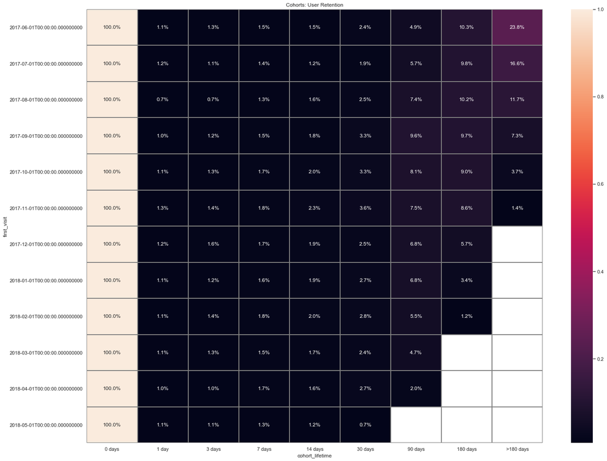

```python
retention_pivot = cohorts.pivot_table(index='first_visit',columns='cohort_lifetime',values='retention',aggfunc='sum')

sns.set(style='white')
plt.figure(figsize=(23, 18))
plt.title('Cohorts: User Retention')
sns.heatmap(retention_pivot, annot=True, fmt='.1%', linewidths=1, xticklabels=lifetime_list, linecolor='gray');
```

`As we see from the heatmap above, most of the users use the service only once and hardly return afterwards. If they do, it happens more than 90 days after initial use.`

##### Conclusion:

907 people use the service daily, 5621 weekly, 23228 monthly in average. The best season is October-March, when service visits spike. Median session time is 5 minutes. People start to return to use the service mostly after a period of 90 days (the best numbers are for September cohort, probably most of which are students), which makes sense due to specifics of the service - people usually do not attend concerts and events every week, rather once in a couple of month, hence the retention rates.

### Sales

##### -When do people start buying?

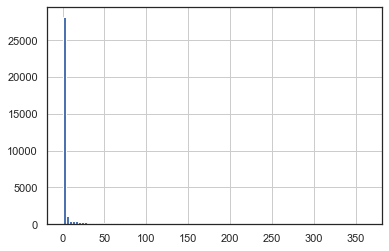

```python
orders_df = orders_df.merge(visits_min, on='uid', how='left')
conv = orders_df.groupby('uid')['order_ts'].min()
conv.name = 'first_order'
orders_df = orders_df.merge(conv, on='uid', how='left')
orders_df['conversion_days'] = (orders_df['first_order'].dt.date - orders_df['first_visit']).dt.days
visits_device = visits_df[['uid','device']].drop_duplicates('uid')
orders_df = orders_df.merge(visits_device, on='uid')
conv_final = orders_df.drop_duplicates('uid')
conv_final['conversion_days'].hist(bins=100)
```

```python
orders_df.query('device == "desktop"')['conversion_days'].mean()
```

```
16.407466301343053
```

```python
orders_df.query('device == "touch"')['conversion_days'].mean()
```

```
22.769028041324056
```

`The vast majority of the people buy tickets the same day they first used the sevice. In average, desktop visitors convert to customers faster, than mobile devices visitors.`

```python
conv_final['first_visit'] = conv_final['first_visit'].astype('datetime64[M]')
```

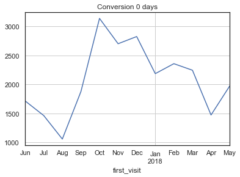

```python
conv_final.query('conversion_days == 0').groupby(['first_visit'])['conversion_days'].count().plot(grid=True, title='Conversion 0 days')
```

`The amount of decisive people who buy tickets the same day they first visit the site spikes in October.`

```python
conv_list = ['0 days', '1 day', '3 days', '7 days', '14 days', '30 days', '>30 days']
def assign_conv_group(days):
    #print(days)
    try:
        if days == 0:
            return 0
        elif days == 1:
            return 1
        elif ((days > 1) and (days <= 3)):
            return 3
        elif ((days > 3) and (days <= 7)):
            return 7
        elif ((days > 7) and (days <= 14)):
            return 14
        elif ((days > 14) and (days <= 30)):
            return 30
        elif days > 30:
            return 360
    except:
        return numpy.nan

conv_final['conv_group'] = conv_final.apply(lambda x: assign_conv_group(x['conversion_days']), axis=1)
```

```python
conversion_pivot = conv_final.pivot_table(index='first_visit',columns='conv_group',values='uid',aggfunc='count')
conversion_pivot.columns = conv_list
```

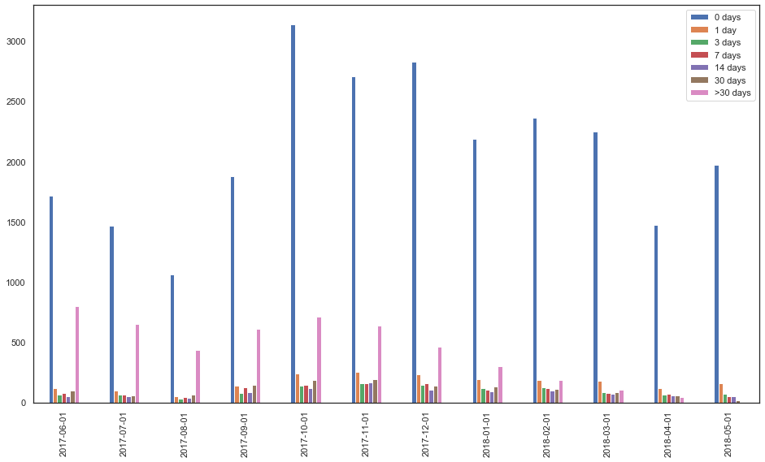

```python
conversion_pivot = conv_final.pivot_table(index='first_visit',columns='conv_group',values='uid',aggfunc='count')
conversion_pivot.columns = conv_list
conversion_pivot.index = pd.to_datetime(conversion_pivot.index).date
conversion_pivot.plot(kind='bar', figsize=(16, 9))
```

`For every cohort, the majority of people become customers the same day. Lets take a look at less decisive customers:`

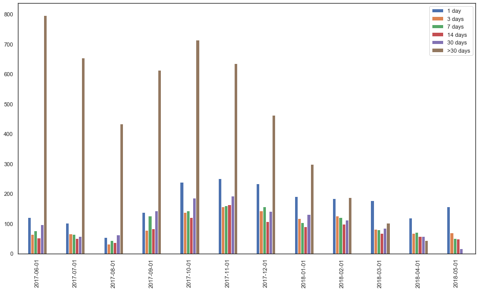

```python
conversion_pivot = conversion_pivot.drop('0 days', 1)
conversion_pivot.plot(kind='bar', figsize=(16, 9))
```

##### -How many orders do they make during a given period of time?

```python
orders_df['order_month'] = orders_df['order_ts'].astype('datetime64[M]')
orders_df['order_week'] = orders_df['order_ts'].astype('datetime64[W]')
orders_df['order_year'] = orders_df['order_ts'].dt.year
```

```python
orders_df.sample()
```

|  | order_ts | revenue | uid | first_visit | first_order | conversion_days | device | order_month | order_week | order_year |
| --- | --- | --- | --- | --- | --- | --- | --- | --- | --- | --- |
| 4131 | 2017-06-29 10:21:00 | 3.67 | 13847304321661765628 | 2017-06-29 | 2017-06-29 10:21:00 | 0 | desktop | 2017-06-01 | 2017-06-29 | 2017 |

```python
orders_df.groupby('order_month').agg({'uid' : 'nunique','revenue' : 'count'})
```

| order_month | uid | revenue |
| --- | --- | --- |
| 2017-06-01 | 2022 | 2353 |
| 2017-07-01 | 1983 | 2362 |
| 2017-08-01 | 1471 | 1803 |
| 2017-09-01 | 2748 | 3383 |
| 2017-10-01 | 4673 | 5677 |
| 2017-11-01 | 4543 | 5644 |
| 2017-12-01 | 4937 | 6206 |
| 2018-01-01 | 3898 | 4721 |
| 2018-02-01 | 4258 | 5280 |
| 2018-03-01 | 4181 | 5325 |
| 2018-04-01 | 2742 | 3265 |
| 2018-05-01 | 3542 | 4344 |

```python
orders_month = orders_df.groupby('order_month').agg({'revenue': ['count', 'sum']})
orders_month
```

| order_month | revenue count | revenue sum |
| --- | --- | --- |
| 2017-06-01 | 2353 | 9557.49 |
| 2017-07-01 | 2362 | 12539.47 |
| 2017-08-01 | 1803 | 8758.78 |
| 2017-09-01 | 3383 | 18345.51 |
| 2017-10-01 | 5677 | 27987.70 |
| 2017-11-01 | 5644 | 27069.93 |
| 2017-12-01 | 6206 | 36388.60 |
| 2018-01-01 | 4721 | 19417.13 |
| 2018-02-01 | 5280 | 25560.54 |
| 2018-03-01 | 5325 | 28834.59 |
| 2018-04-01 | 3265 | 16858.06 |
| 2018-05-01 | 4344 | 20735.98 |

```
mean 4196.916666666667 min 1803 max 6206
```

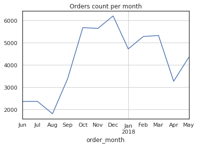

```python
orders_month[('revenue', 'count')].plot(grid=True, title='Orders count per month')
print('mean', orders_month[('revenue', 'count')].mean(), 'min',
      orders_month[('revenue', 'count')].min(), 'max',
      orders_month[('revenue', 'count')].max())
```

`Maximum orders count per month is 6200 in December, the minimum is 1800 in August. The average order count per month is around 4200 orders.`

```
mean 950.2452830188679 min 318 max 2111
```

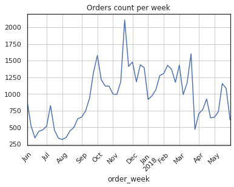

```python
orders_week = orders_df.groupby(['order_week']).agg({'revenue': ['count', 'sum']})
orders_week[('revenue', 'count')].plot(grid=True, rot=45, title='Orders count per week')
print('mean', orders_week[('revenue', 'count')].mean(), 'min',
      orders_week[('revenue', 'count')].min(), 'max',
      orders_week[('revenue', 'count')].max())
```

`Maximum orders count per week is above 2100 in the third week of November, the minimum is 318 in the beginning of August. The average order count per week is around 950 orders.`

```
mean 138.7410468319559
min 15 on 2018-03-30
max 814 on 2017-11-24
```

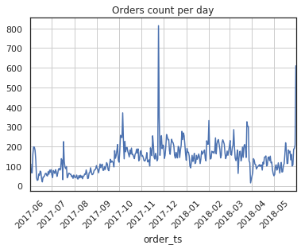

```python
orders_day = orders_df.groupby(orders_df['order_ts'].dt.date).agg({'revenue': ['count', 'sum']})
orders_day[('revenue', 'count')].plot(grid=True, rot=45, title='Orders count per day')
print('mean', orders_day[('revenue', 'count')].mean(), '\nmin',
      orders_day[('revenue', 'count')].min(), 'on', orders_day[('revenue', 'count')].idxmin(),
      '\nmax', orders_day[('revenue', 'count')].max(), 'on', orders_day[('revenue', 'count')].idxmax())
```

`Maximum orders count per day is 814 on November, 24, spiking very high above the average of 140 orders. The minimum was 15 on March, 30.`

##### -What is the average purchase size?

```python
orders_df['revenue'].mean()
```

```
5.004741179040169
```

```python
avg_rev = orders_df.groupby('order_month').agg({'revenue':'mean'})
avg_rev
```

| order_month | revenue |
| --- | --- |
| 2017-06-01 | 4.061832 |
| 2017-07-01 | 5.308836 |
| 2017-08-01 | 4.857892 |
| 2017-09-01 | 5.422852 |
| 2017-10-01 | 4.930016 |
| 2017-11-01 | 4.796231 |
| 2017-12-01 | 5.863455 |
| 2018-01-01 | 4.112927 |
| 2018-02-01 | 4.841011 |
| 2018-03-01 | 5.414946 |
| 2018-04-01 | 5.163265 |
| 2018-05-01 | 4.773476 |

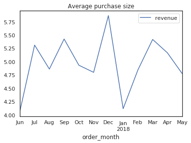

```python
avg_rev.plot(title='Average purchase size')
```

`An average purchase size is 5 (Rub, I guess. The currency wasn't stated). It also doesn't change much during the year, probably this is the commission the service receives per purchase.`

##### -How much money do they bring? (LTV)

```python
orders_df['first_order'] = orders_df['first_order'].astype('datetime64[M]')
cohort_sizes = orders_df.groupby('first_order').agg({'uid': 'nunique'}).reset_index()
cohort_sizes.columns = ['first_order_month', 'n_buyers']
cohort_sizes
```

|  | first_order_month | n_buyers |
| --- | --- | --- |
| 0 | 2017-06-01 | 2022 |
| 1 | 2017-07-01 | 1922 |
| 2 | 2017-08-01 | 1369 |
| 3 | 2017-09-01 | 2579 |
| 4 | 2017-10-01 | 4340 |
| 5 | 2017-11-01 | 4078 |
| 6 | 2017-12-01 | 4380 |
| 7 | 2018-01-01 | 3373 |
| 8 | 2018-02-01 | 3651 |
| 9 | 2018-03-01 | 3534 |
| 10 | 2018-04-01 | 2274 |
| 11 | 2018-05-01 | 2986 |

```python
cohorts = orders_df.groupby([orders_df['first_order'],'order_month']).agg({'revenue': 'sum'}).reset_index()
cohorts.head()
```

|  | first_order | order_month | revenue |
| --- | --- | --- | --- |
| 0 | 2017-06-01 | 2017-06-01 | 9557.49 |
| 1 | 2017-06-01 | 2017-07-01 | 981.82 |
| 2 | 2017-06-01 | 2017-08-01 | 885.34 |
| 3 | 2017-06-01 | 2017-09-01 | 1931.30 |
| 4 | 2017-06-01 | 2017-10-01 | 2068.58 |

```python
cohorts.columns = ['first_order_month', 'order_month', 'revenue']
```

```python
margin_rate = 0.4 #Average rate on market, was not given in data or description

report = pd.merge(cohort_sizes, cohorts, on='first_order_month')
report['gp'] = report['revenue'] * margin_rate
report['age'] = (report['order_month'] - report['first_order_month']) / np.timedelta64(1, 'M')#.astype(int)
report['age'] = report['age'].round().astype('int')
report.head()
```

|  | first_order_month | n_buyers | order_month | revenue | gp | age |
| --- | --- | --- | --- | --- | --- | --- |
| 0 | 2017-06-01 | 2022 | 2017-06-01 | 9557.49 | 3822.996 | 0 |
| 1 | 2017-06-01 | 2022 | 2017-07-01 | 981.82 | 392.728 | 1 |
| 2 | 2017-06-01 | 2022 | 2017-08-01 | 885.34 | 354.136 | 2 |
| 3 | 2017-06-01 | 2022 | 2017-09-01 | 1931.30 | 772.520 | 3 |
| 4 | 2017-06-01 | 2022 | 2017-10-01 | 2068.58 | 827.432 | 4 |

```python
report['ltv'] = report['gp'] / report['n_buyers']

output = report.pivot_table(
    index='first_order_month',
    columns='age',
    values='ltv',
    aggfunc='mean')#.round()


output = output.cumsum(axis=1)
output.fillna('')
```

[output not shown]

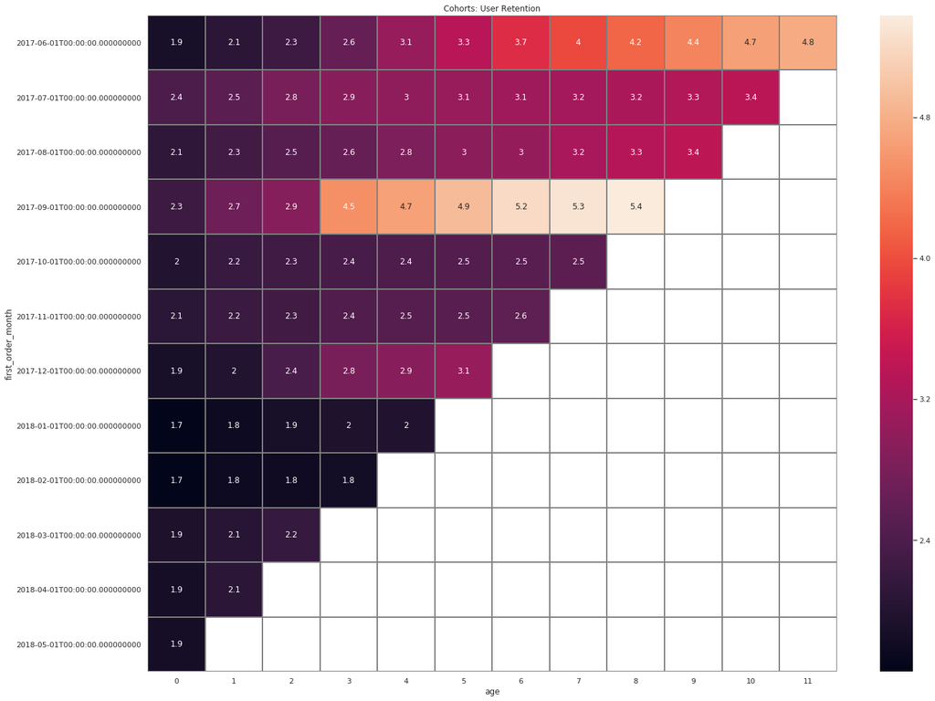

```python
sns.set(style='white')
plt.figure(figsize=(23, 18))
plt.title('Cohorts: User Retention')
sns.heatmap(output, annot=True, linewidths=1, linecolor='gray');
```

`On the heatmap above we see that most purchases occure in cohorts with 0 month age - people buy once after first visit and do not return. However there is one clear outlier for the September cohort at 3 month age - just befoore the holidays season. I assume most of the cohort are students, and they wish to have fun at some holiday events before the exam period started.`

##### Conclusion:

Most of the people make their first purchase the same day they first visit the servise. This rate rises in October and stays high until the end of the year holidays.  
The amount of orders stays above 5000 per month from October to March, with a little drop in January.  
The average purchse size remains roughly the same throughout the year - around 5.  
After initial purchase (which is around 2 rub per user), LTV continue to grow slowly due to small retention, and may reach around 5 rub for 12 month old cohort, with some exception (September cohort).

### Marketing

##### -How much money was spent? Overall/per source/over time

```python
costs_df['costs'].sum()
```

```
329131.62
```

```python
costs_df.groupby('source_id')['costs'].sum().reset_index()
```

|  | source_id | costs |
| --- | --- | --- |
| 0 | 1 | 20833.27 |
| 1 | 2 | 42806.04 |
| 2 | 3 | 141321.63 |
| 3 | 4 | 61073.60 |
| 4 | 5 | 51757.10 |
| 5 | 9 | 5517.49 |
| 6 | 10 | 5822.49 |

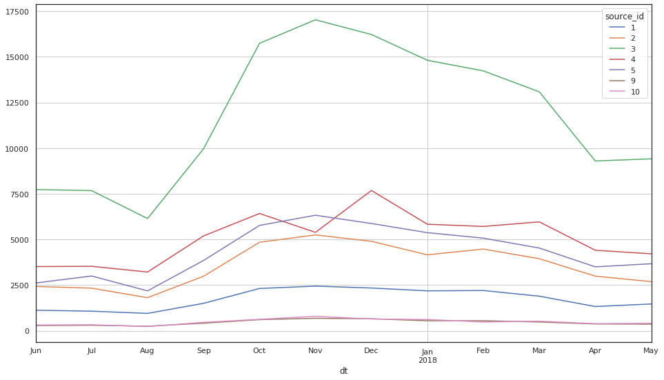

```python
costs_df.pivot_table(index=costs_df['dt'].astype('datetime64[M]'),
                     values='costs', columns='source_id', aggfunc='sum').plot(figsize=(16, 9), grid=True)
```

`329131.62 rub was spent ono the marketing in 12 months. Most of the money went on the marketing channel #3 - 141000, the least amount os for #9 and #10 (only about 6000). Summer was a dead season for marketing expences, in September they started to rise, reaching a peak in November.`

##### How much did customer acquisition from each of the sources cost?

```python
vdf = visits_df.drop_duplicates('uid').groupby(['source_id', 'day'])['uid'].nunique().reset_index()
vdf['day'] = vdf['day'].astype('datetime64')
new_df = pd.merge(vdf, costs_df,  how='left', left_on=['source_id','day'], right_on = ['source_id','dt'])
new_df.info()
```

```
<class 'pandas.core.frame.DataFrame'>
Int64Index: 2568 entries, 0 to 2567
Data columns (total 5 columns):
source_id    2568 non-null int64
day          2568 non-null datetime64[ns]
uid          2568 non-null int64
dt           2534 non-null datetime64[ns]
costs        2534 non-null float64
dtypes: datetime64[ns](2), float64(1), int64(2)
memory usage: 120.4 KB
```

```python
new_df.query('dt != dt').head(10)
```

|  | source_id | day | uid | dt | costs |
| --- | --- | --- | --- | --- | --- |
| 303 | 1 | 2018-03-31 | 1 | NaT | NaN |
| 1816 | 6 | 2017-07-01 | 1 | NaT | NaN |
| 1817 | 6 | 2017-11-12 | 1 | NaT | NaN |
| 1818 | 7 | 2017-06-06 | 1 | NaT | NaN |
| 1819 | 7 | 2017-06-19 | 1 | NaT | NaN |
| 1820 | 7 | 2017-07-05 | 1 | NaT | NaN |
| 1821 | 7 | 2017-07-29 | 1 | NaT | NaN |
| 1822 | 7 | 2017-08-17 | 1 | NaT | NaN |
| 1823 | 7 | 2017-09-22 | 1 | NaT | NaN |
| 1824 | 7 | 2017-09-28 | 1 | NaT | NaN |

```python
new_df = new_df.drop('dt', 1)
new_df['costs'] = new_df['costs'].fillna(0)#, inplace=True)
```

```python
cac_total = new_df.groupby(['source_id']).agg({'uid':'sum', 'costs':'sum'})
cac_total['source_cac'] = cac_total['costs'] / cac_total['uid']
cac_total
```

| source_id | uid | costs | source_cac |
| --- | --- | --- | --- |
| 1 | 9469 | 20833.27 | 2.200155 |
| 2 | 17616 | 42806.04 | 2.429952 |
| 3 | 66116 | 141321.63 | 2.137480 |
| 4 | 72346 | 61073.60 | 0.844188 |
| 5 | 49237 | 51756.40 | 1.051169 |
| 6 | 2 | 0.00 | 0.000000 |
| 7 | 32 | 0.00 | 0.000000 |
| 9 | 6448 | 5454.42 | 0.845909 |
| 10 | 6903 | 5821.12 | 0.843274 |

`Channel #2 was the most expensive with 2.4 rub per customer attracted. But it was not the most efficient one - it attracted 17616 customers vs 72346 from the channel #4, which also was not that expensive, only 0.84 per customer.`

##### How worthwhile where the investments? (ROI)

```python
visits = visits_df[['uid', 'source_id']]
visits = visits.drop_duplicates('uid')
orders_df = orders_df.merge(visits, on='uid', how='left')
source_cohort = orders_df.groupby(['source_id', 'first_visit']).agg({'revenue':'sum', 'uid':'count'}).reset_index()
```

```python
d = orders_df['first_visit'].iloc[0]
orders_df.query('first_visit == @d and source_id == 1')['revenue'].sum()
```

```
3971.04
```

```python
source_cohort['first_visit'] = source_cohort['first_visit'].astype('datetime64')
romi_df = pd.merge(source_cohort, costs_df, left_on=['source_id', 'first_visit'], right_on=['source_id', 'dt'])
```

```python
romi_df['week'] = romi_df['first_visit'].astype('datetime64[W]')
romi_df['month'] = romi_df['first_visit'].astype('datetime64[M]')
romi_grouped = romi_df.pivot_table(index='source_id',  values=['revenue', 'costs'], aggfunc='sum')
```

```python
romi_grouped
```

| source_id | costs | revenue |
| --- | --- | --- |
| 1 | 20790.03 | 31090.55 |
| 2 | 42690.36 | 46923.61 |
| 3 | 141321.63 | 54511.24 |
| 4 | 61057.91 | 56693.41 |
| 5 | 51756.40 | 52624.02 |
| 9 | 4197.85 | 5759.40 |
| 10 | 5401.28 | 4450.33 |

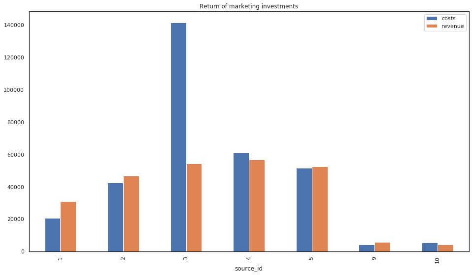

```python
romi_grouped.plot(figsize=(16,9), kind='bar', title='Return of marketing investments')
```

`As we see from the graph above, the investments in marketing are not paying off for some sources. Worst case is channel #3, which costs are almost thrice of it's revenue. Channels 1, 2, 5, 9 may be considered as succesful marketing investments, their revenues are greater than costs.`

##### Conclusion

330000 rub was the marketing cost for 12 months, almost half of those money wen on source #3. This investment did not payed off, the revenue from this channel is very low relative to investments - almost 55000. But it is the second biggest revenue among the channels.

## Step 3. An overall conclusion.

As seen on the chart above, there are some of the marketing channesl were a failure, and it would be a good idea to reallocate those investments to other sources.

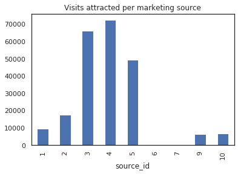

```python
visits_df.drop_duplicates('uid').groupby('source_id')['uid'].nunique().plot(kind='bar', title='Visits attracted per marketing source')
```

- In terms of visits channel #3 is the second most succesful. But all those visits brought a very small amount of revenue. I recommend to cut the marketing expenses on this channel significantly.
- Source #4 marketing costs were slightly bigger than a revenue generated by this channel, but this channel brought the best visits quantity, so in terms of brand recognition this channel is a great success. We should possibly invest more in this channel.
- Source #5 brought slightly more money than was invested and is on third place in visitors attracted, definetly a good source to invest more.
- Sources #9 and #10 are the smallest investments. #9 slightly paid off, #10 did not. They both attracted a similar amount of users, so probably #9 should be infused a little bit more.

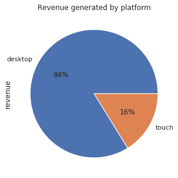

```python
orders_df.groupby('device')['revenue'].sum().plot(kind='pie', autopct='%1.0f%%', figsize=(8, 5), title='Revenue generated by platform')
```

The greater share of revenue is generated by desktop users.

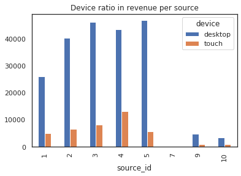

```python
orders_df.pivot_table(index='source_id', columns='device', values='revenue', aggfunc='sum').plot(kind='bar', title='Device ratio in revenue per source')
```

Channel #4 attracts more mobile device users than any other channel, both in terms of share and quantity. So we should focus on advertising on this source for mobile users.